# Lab_5

Могильников Дмитрий

2022-12-17

## Задание 1

### Сформируйте датасет самостоятельно на основе погодных данных (например, с сайта rp5).

С сайта rp5 были взяты данные города Нижневартовск за последние пять лет. Произведен парсинг этих данных в отдельный csv файл, в котором выделены два столбца:

- Дата
- Минимальная температура за сутки

Загрузим полученный датасет:

```r
options(width = 100)
library(forecast)
library(lubridate)
df_min_temp <- read.csv('Nizhnevartovsk_min_temperature.csv', sep=',', header = TRUE)
head(df_min_temp, 20)
```

```
##          date min_temperature
## 1  2017-12-17            -9.8
## 2  2017-12-18           -12.7
## 3  2017-12-19            -9.1
## 4  2017-12-20           -13.3
## 5  2017-12-21           -10.5
## 6  2017-12-22            -9.3
## 7  2017-12-23            -8.0
## 8  2017-12-24            -9.4
## 9  2017-12-25           -15.0
## 10 2017-12-26           -19.9
## 11 2017-12-27           -24.4
## 12 2017-12-28           -26.4
## 13 2017-12-29           -19.6
## 14 2017-12-30           -23.9
## 15 2017-12-31           -27.0
## 16 2018-01-01           -13.7
## 17 2018-01-02           -20.2
## 18 2018-01-03           -36.1
## 19 2018-01-04           -25.4
## 20 2018-01-05            -8.4
```

```r
#Спарсим первую колонку в правильное значение даты
df_min_temp$date <- as.Date(df_min_temp$date, "%Y-%m-%d")
```

## Задание 2

### Создайте на основе датасета одномерный временной ряд. Выведите его на графике.

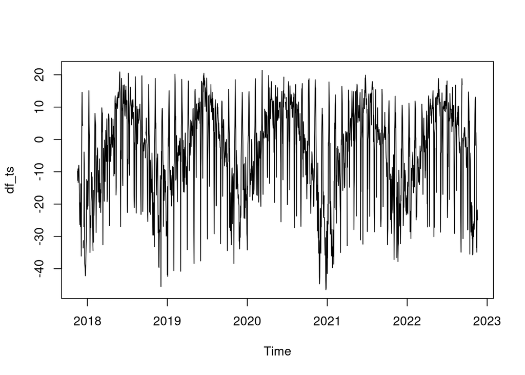

```r
#Сформируем time-series, начиная с 2017-11-17
df_ts = ts(df_min_temp$min_temperature,
           frequency=365,
           start=decimal_date(ymd("2017-11-17")),
)

#Построим временной ряд:
plot(df_ts)
```

```r
# Видим, что наблюдается сезонная периодичность, что естественно

#создадим переменную с датами
time <- time(df_ts)

#разделим на тестовую (15% ~270 элементов) и тестовую выборку
n_test <- 270
n_train <- length(df_ts) - n_test
df_train <- window(df_ts, start=time[1], end=time[n_train])
df_test <- window(df_ts, start=time[n_train+1], end=time[n_train+n_test])
```

## Задание 3

### Смоделируйте ряд тремя разными методами на Ваш выбор (naïve, snaive, ar, ma, arima, ses и т.д.).

```r
# библиотека для проверки accuracy построенных моделей
library(knitr)
# Смоделируем наивную модель, h - сколько значений хотим предсказать(для сравнения с тестовой выборкой)
df_naive <- naive(df_train, h=n_test)

# Построим сезонную модель
df_snaive <- snaive(df_train, h=n_test)

# Рассчитаем accuracy для каждой модели
acc_naive <- accuracy(df_naive, df_test)
acc_snaive <- accuracy(df_snaive, df_test)

# Воспользуемся методом ARIMA: для начала рассмотрим автоматическую регрессию
df_ar <- arima(df_train, c(1,0,0))
df_ar_res <-predict(df_ar, n.ahead=n_test)
acc_ar <- accuracy(df_ar_res$pred, df_test)

# Рассмотрим скользящее среднее
df_ma <- arima(df_train, c(0,0,1))
df_ma_res <-predict(df_ma, n.ahead=n_test)
acc_ma <- accuracy(df_ma_res$pred, df_test)

# Рассмотрим полную ARIMA
df_arima <- arima(df_train, c(1,1,1))
df_arima_res <-predict(df_arima, n.ahead=n_test)
acc_arima <- accuracy(df_arima_res$pred, df_test)
```

## Задание 4

### Оцените точность прогнозирования построенных моделей (размер обучающей и тестовой выборок на Ваш выбор). Выберите наилучших метод.

```r
# Сравним полученные результаты:
# Наивная модель
kable(acc_naive)
```

|  | ME | RMSE | MAE | MPE | MAPE | MASE | ACF1 | Theil’s U |
| --- | --- | --- | --- | --- | --- | --- | --- | --- |
| Training set | -0.0019506 | 9.544966 | 6.578284 | NaN | Inf | 0.8217388 | -0.123298 | NA |
| Test set | 11.5165414 | 18.010740 | 16.355639 | 128.7663 | 424.4798 | 2.0430957 | 0.728016 | 1.955996 |

```r
# Сезонная модель
kable(acc_snaive)
```

|  | ME | RMSE | MAE | MPE | MAPE | MASE | ACF1 | Theil’s U |
| --- | --- | --- | --- | --- | --- | --- | --- | --- |
| Training set | 0.2049404 | 10.849156 | 7.999489 | NaN | Inf | 0.9992714 | 0.4754047 | NA |
| Test set | -0.1612782 | 7.737141 | 5.843985 | -12.07144 | 122.0261 | 0.7300125 | 0.3315575 | 0.6505751 |

```r
# Авторегрессионная модель
kable(acc_ar)
```

|  | ME | RMSE | MAE | MPE | MAPE | ACF1 | Theil’s U |
| --- | --- | --- | --- | --- | --- | --- | --- |
| Test set | 3.182797 | 14.15237 | 12.01099 | 108.5145 | 186.6458 | 0.7268222 | 1.146815 |

```r
# Скользящее среднее
kable(acc_ma)
```

|  | ME | RMSE | MAE | MPE | MAPE | ACF1 | Theil’s U |
| --- | --- | --- | --- | --- | --- | --- | --- |
| Test set | 3.118175 | 14.18165 | 12.08093 | 109.7035 | 187.573 | 0.7286398 | 1.148454 |

```r
# Полная ARIMA
kable(acc_arima)
```

|  | ME | RMSE | MAE | MPE | MAPE | ACF1 | Theil’s U |
| --- | --- | --- | --- | --- | --- | --- | --- |
| Test set | 9.084532 | 16.54989 | 14.96706 | 123.0399 | 353.8403 | 0.7278388 | 1.678547 |

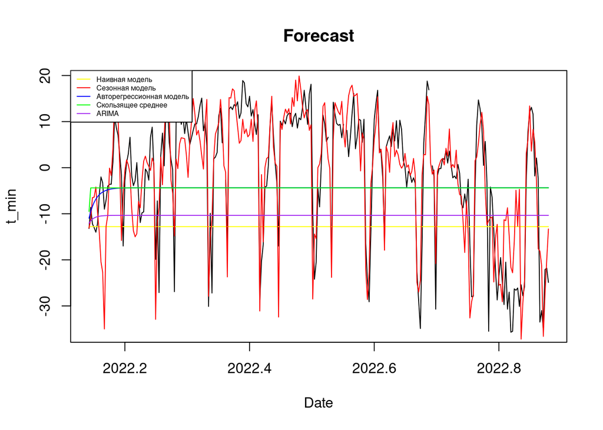

```r
plot(df_test, main="Forecast", xlab="Date", ylab="t_min")
lines(df_naive$mean, col="yellow")
lines(df_snaive$mean, col="red")
lines(df_ar_res$pred, col="blue")
lines(df_ma_res$pred, col="green")
lines(df_arima_res$pred, col="purple")
legend("topleft",
       legend=c("Наивная модель", "Сезонная модель", "Авторегрессионная модель", "Скользящее среднее", "ARIMA"),
       col=c("yellow", "red", "blue", "green", "purple"), lty = 1:1, cex=0.5)
```

Исходя из полученных результатов, мы можем сделать вывод, что для прогнозирования погоды лучше всего подходит сезонная модель, это связанно с тем, что только она учитывает необходимые сезонные изменения. У остальных моделей показатели MAE и RMSE хуже, а также на графике видно, что для такого небольшого промежутка времени они все сходятся к константе. Сезонная модель же достаточно хорошо соотносится с тестовой выборкой.

## Задание 5

### Сформируйте дополнительный датасет на основе первого, возьмите данные только за определенный сезон (весна, лето, осень, зима) минимально за последние 5 лет.

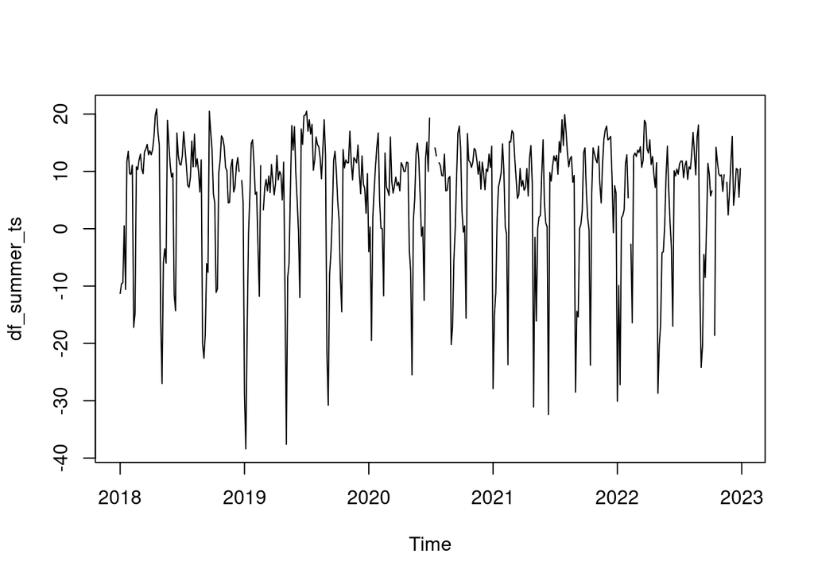

```r
#Возьмем данные за лето, что поможет немного устранить сезонную компоненту.
df_summer <- (subset(df_min_temp, month(df_min_temp$date)>5 & month(df_min_temp$date)<9))

#Сформируем time-series, начиная с 2017-11-17
df_summer_ts = ts(df_summer$min_temperature,
           frequency=92,
           start = c(2018, 1)
)

#Построим временной ряд:
plot(df_summer_ts)
```

```r
# Видим, что наблюдается сезонная периодичность, что естественно

#создадим переменную с датами
time_summer <- time(df_summer_ts)

#разделим на тестовую (15% ~60 элементов) и тестовую выборку
n_test_summer <- 60
n_train_summer <- length(df_summer_ts) - n_test_summer
df_train_summer <- window(df_summer_ts, start=time_summer[1], end=time_summer[n_train_summer])
df_test_summer <- window(df_summer_ts, start=time_summer[n_train_summer+1], end=time_summer[n_train_summer+n_test_summer])
```

## Задание 6

### Те же пункты 2-4 ко второму датасету.

```r
# Смоделируем наивную модель, h - сколько значений хотим предсказать(для сравнения с тестовой выборкой)
df_naive_summer <- naive(df_train_summer, h=n_test_summer)

# Построим сезонную модель
df_snaive_summer <- snaive(df_train_summer, h=n_test_summer)

# Рассчитаем accuracy для каждой модели
acc_naive_summer <- accuracy(df_naive_summer, df_test_summer)
acc_snaive_summer <- accuracy(df_snaive_summer, df_test_summer)

# Воспользуемся методом ARIMA: для начала рассмотрим автоматическую регрессию
df_ar_summer <- arima(df_train_summer, c(1,0,0))
df_ar_res_summer <-predict(df_ar_summer, n.ahead=n_test_summer)
acc_ar_summer <- accuracy(df_ar_res_summer$pred, df_test_summer)

# Рассмотрим скользящее среднее
df_ma_summer <- arima(df_train_summer, c(0,0,1))
df_ma_res_summer <-predict(df_ma_summer, n.ahead=n_test_summer)
acc_ma_summer <- accuracy(df_ma_res_summer$pred, df_test_summer)

# Рассмотрим полную ARIMA
df_arima_summer <- arima(df_train_summer, c(1,1,1))
df_arima_res_summer <-predict(df_arima_summer, n.ahead=n_test_summer)
acc_arima_summer <- accuracy(df_arima_res_summer$pred, df_test_summer)

# Сравним полученные результаты:
# Наивная модель
kable(acc_naive_summer)
```

|  | ME | RMSE | MAE | MPE | MAPE | MASE | ACF1 | Theil’s U |
| --- | --- | --- | --- | --- | --- | --- | --- | --- |
| Training set | -0.0229008 | 10.93955 | 6.692621 | NaN | Inf | 1.365187 | -0.2172618 | NA |
| Test set | 25.7931034 | 27.54554 | 25.934483 | 380.9682 | 448.3189 | 5.290216 | 0.5136105 | 3.309321 |

```r
# Сезонная модель
kable(acc_snaive_summer)
```

|  | ME | RMSE | MAE | MPE | MAPE | MASE | ACF1 | Theil’s U |
| --- | --- | --- | --- | --- | --- | --- | --- | --- |
| Training set | -0.1758278 | 7.129848 | 4.936755 | NaN | Inf | 1.007018 | 0.2609642 | NA |
| Test set | -1.3327586 | 6.305375 | 4.791379 | -33.3399 | 73.11252 | 0.977364 | 0.2759359 | 0.3927724 |

```r
# Авторегрессионная модель
kable(acc_ar_summer)
```

|  | ME | RMSE | MAE | MPE | MAPE | ACF1 | Theil’s U |
| --- | --- | --- | --- | --- | --- | --- | --- |
| Test set | 0.0030318 | 9.127295 | 6.615603 | 18.5837 | 94.32836 | 0.5079397 | 0.7352167 |

```r
# Скользящее среднее
kable(acc_ma_summer)
```

|  | ME | RMSE | MAE | MPE | MAPE | ACF1 | Theil’s U |
| --- | --- | --- | --- | --- | --- | --- | --- |
| Test set | -0.5364362 | 9.522379 | 6.944464 | 15.01676 | 107.9061 | 0.5220547 | 0.7030992 |

```r
# Полная ARIMA
kable(acc_arima_summer)
```

|  | ME | RMSE | MAE | MPE | MAPE | ACF1 | Theil’s U |
| --- | --- | --- | --- | --- | --- | --- | --- |
| Test set | 0.0124203 | 9.124127 | 6.610899 | 18.75644 | 94.00066 | 0.5077359 | 0.7366301 |

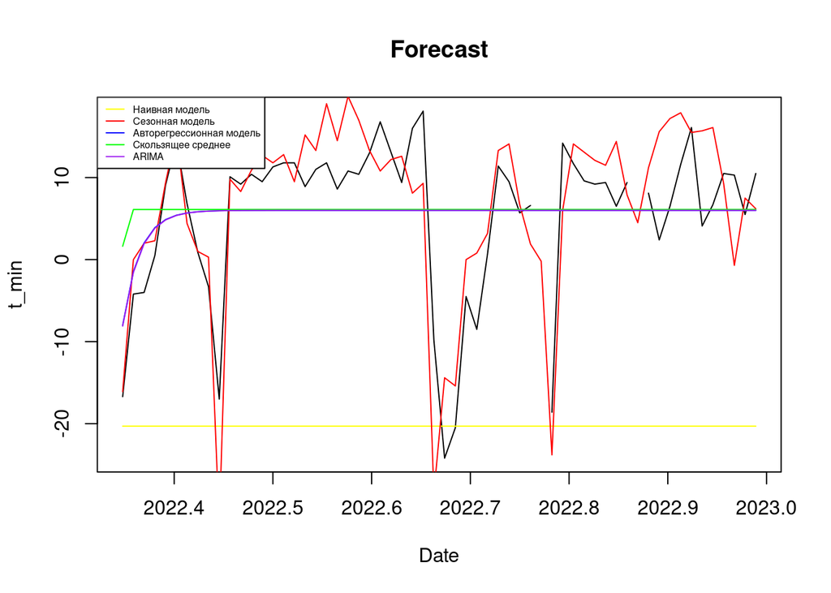

```r
plot(df_test_summer, main="Forecast", xlab="Date", ylab="t_min")
lines(df_naive_summer$mean, col="yellow")
lines(df_snaive_summer$mean, col="red")
lines(df_ar_res_summer$pred, col="blue")
lines(df_ma_res_summer$pred, col="green")
lines(df_arima_res_summer$pred, col="purple")
legend("topleft",
       legend=c("Наивная модель", "Сезонная модель", "Авторегрессионная модель", "Скользящее среднее", "ARIMA"),
       col=c("yellow", "red", "blue", "green", "purple"), lty = 1:1, cex=0.5)
```

Исходя из полученных результатов, мы можем сделать вывод, что наилучший результат прогнозирования погоды для одного сезона также дает сезонная модель. У остальных моделей показатели MAE и RMSE хуже, а также на графике видно, что для такого небольшого промежутка времени они все сходятся к константе. Сезонная модель же достаточно хорошо соотносится с тестовой выборкой.